# Using models 1

Devon Parsons

```r
knitr::opts_chunk$set(echo = TRUE)
```

```r
require(here)

catrate <- read.csv(here("data", "catrate.csv"))

head(catrate)

summary(catrate)
```

[output not shown]

# #1

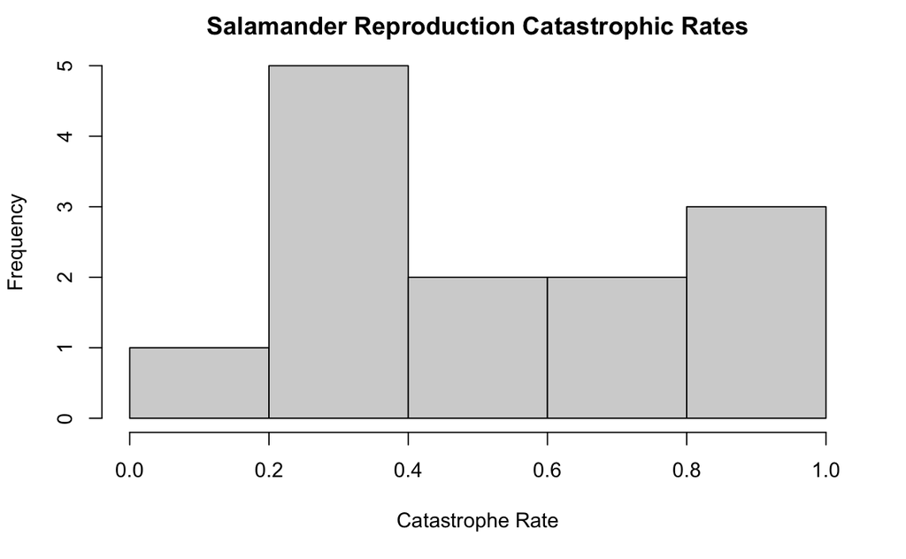

```r
hist(catrate$cat.rate, main = "Salamander Reproduction Catastrophic Rates", xlab = "Catastrophe Rate")
```

# #2

```r
shapiro.test(catrate$cat.rate)
```

```
    Shapiro-Wilk normality test

data:  catrate$cat.rate
W = 0.86202, p-value = 0.04097
```

# #3

Null hypothesis- the data were sampled from a normally distributed population

# #4

If I made a significance value of 0.05, the p-value is smaller than that value meaning its very likely our sample came from a non normally distributed population.

# #5

```r
t.test(x = catrate$cat.rate, mu = 0.28, alternative = "greater")
```

```
    One Sample t-test

data:  catrate$cat.rate
t = 3.0261, df = 12, p-value = 0.005271
alternative hypothesis: true mean is greater than 0.28
95 percent confidence interval:
 0.3866123       Inf
sample estimates:
mean of x
0.5393773
```

```r
t.test(x = catrate$cat.rate, mu = 0.28, alternative = "less")
```

```
    One Sample t-test

data:  catrate$cat.rate
t = 3.0261, df = 12, p-value = 0.9947
alternative hypothesis: true mean is less than 0.28
95 percent confidence interval:
      -Inf 0.6921422
sample estimates:
mean of x
0.5393773
```

# #6

The null hypothesis for the t test is that the catastrophic rate is the same as the pond-late filling rate.

# #7

This is a one-tailed test, as I tested for the possibility of the relationship being greater than. P value is smaller than .05

# #8

# #9

# #10

Since the p-value is much smaller than the significance value of .05, I can conclude that there is strong evidence to reject the null hypothesis.

# #11

```r
wilcox.test(catrate$cat.rate, mu = 2 / 7)
```

```
    Wilcoxon signed rank test with continuity correction

data:  catrate$cat.rate
V = 85, p-value = 0.006275
alternative hypothesis: true location is not equal to 0.2857143
```

# #12

# #13

Since the p-value from the Wilcox test (.006275) is smaller than our significance value of .05, there is strong evidence to reject the null hypothesis.

# #14

# #15

# #16

```r
require(palmerpenguins)
dat_penguins = droplevels(subset(penguins, species != "Gentoo"))
dat_chinstrap <- subset(dat_penguins, species == "Chinstrap")
shapiro.test(dat_chinstrap$flipper_length_mm)
```

```
    Shapiro-Wilk normality test

data:  dat_chinstrap$flipper_length_mm
W = 0.98891, p-value = 0.8106
```

```r
dat_adelie <- subset(dat_penguins, species == "Adelie")
shapiro.test(dat_adelie$flipper_length_mm)
```

```
    Shapiro-Wilk normality test

data:  dat_adelie$flipper_length_mm
W = 0.99339, p-value = 0.72
```

# #17

The p value for Chinstrap is .8106, and for Adelie it is .72. Both of the p values are larger than the significance value of .05, so we can not reject the null hypothesis. We can conclude that for both species, the flipper lengths are normally distributed.

# #18

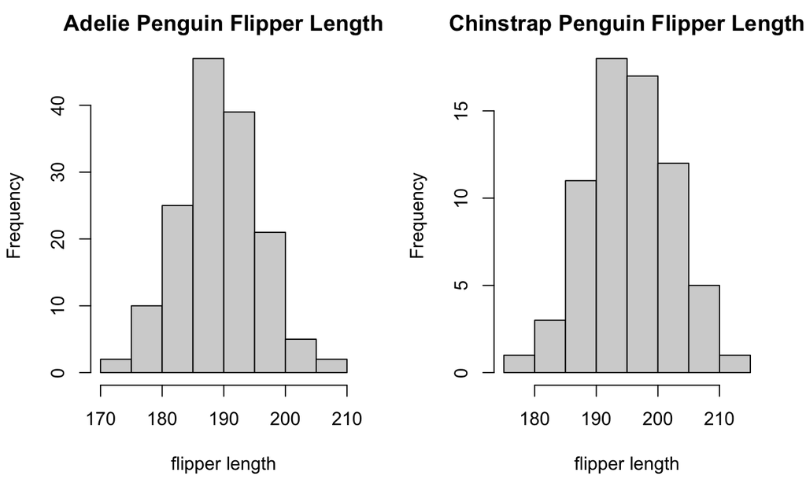

```r
par(mfrow = c(1, 2))
hist(dat_adelie$flipper_length_mm, main = "Adelie Penguin Flipper Length", xlab = "flipper length")
hist(dat_chinstrap$flipper_length_mm, main = "Chinstrap Penguin Flipper Length", xlab = "flipper length")
```

# #19

The alternative hypothesis is that the flipper length between the Adelie and Chinstrap penguins are not the same. This is a two tailed test because a direction is not specified, like if the flipper length is greater or less than a certain number.

# #20

```r
t.test(dat_penguins$flipper_length_mm ~ dat_penguins$species)
```

[output not shown]